# Insert title of project here

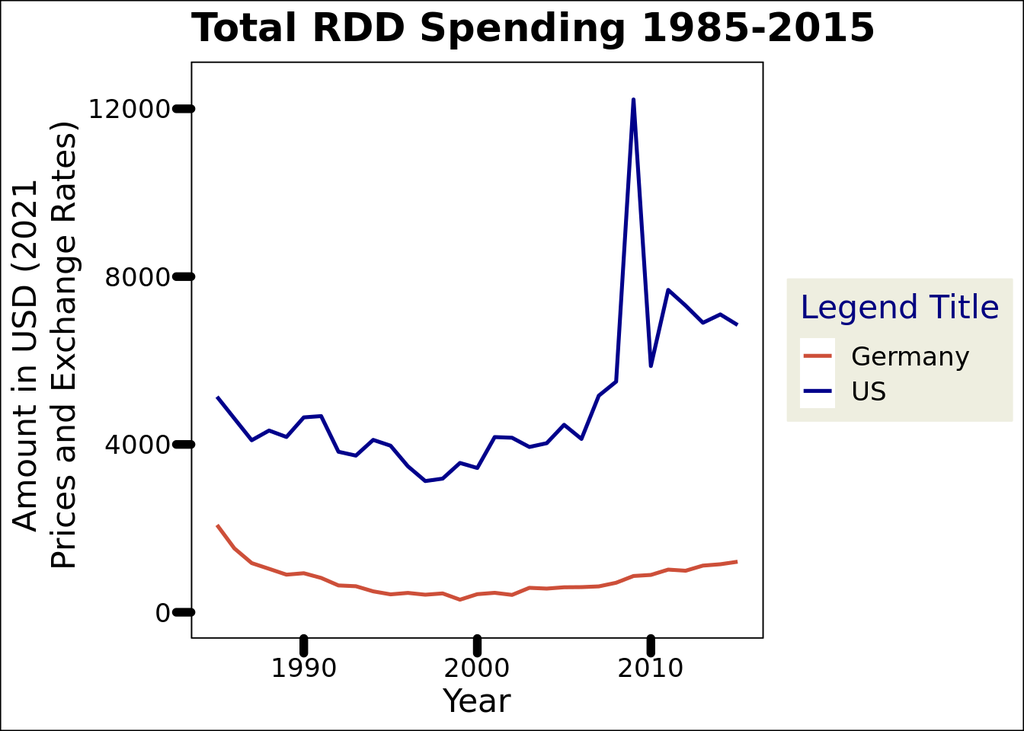

US and Germany Total RDD Spending 1985 to 2015. Line graph used to visualize potential trends.

```r
# Germ and US Line Plot
US.Germ.total.plot <- ggplot(US.and.Germany.RDD,
                              aes(x = Date,
                                  y = Total.Budget,
                                  color = Country)) +
  geom_line(size= 0.9) +
  ylim(0, 12500) +
  scale_color_manual(values = c("tomato3", "darkblue")) +
  labs(title = "Total RDD Spending 1985-2015",
       y="Amount in USD (2021 \n Prices and Exchange Rates)",
       x="Year",
       color= "Legend Title")
print(US.Germ.total.plot)
```

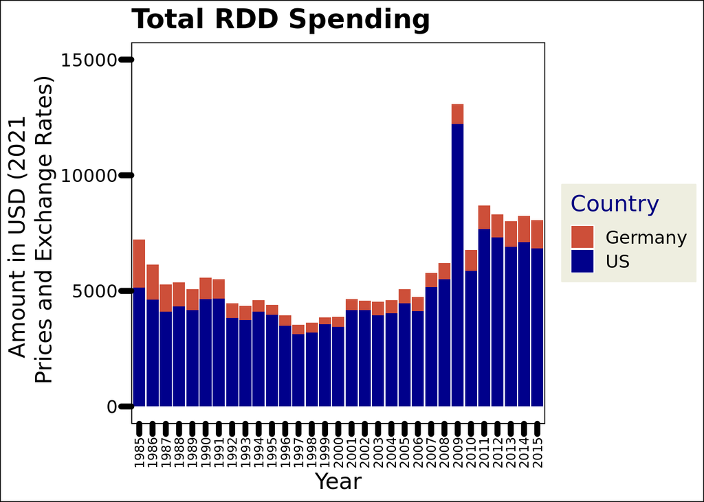

US and Germany Total RDD Spending 1985 to 2015. Bar graph used to visually compare relative magnitude of total spending.

```r
# Create the US and Germ Total bar plot
US.Germ.total.Bar.plot <- ggplot(US.and.Germany.RDD, aes(x = Year, y= Total.Budget, fill= Country)) +
  geom_bar(stat= "identity", position = "stack") +
  geom_bar(stat= "identity", position = "stack") +
  scale_fill_manual(values = c("tomato3", "darkblue")) +
  ylim(0, 15000) +
  labs(fill = "Country")+
  theme(axis.text.x = element_text(angle = 90, vjust = 0.5, hjust=1, size = 9)) +
  labs(title = "Total RDD Spending",
       y="Amount in USD (2021 \n Prices and Exchange Rates)",
       x="Year")
print(US.Germ.total.Bar.plot)
```

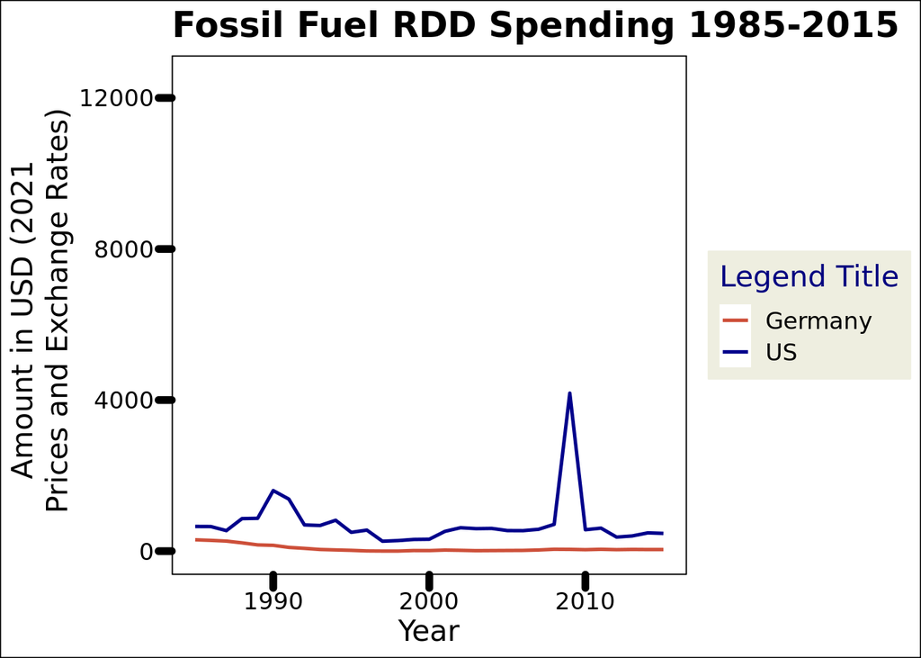

US and Germany Fossil Fuel RDD Spending 1985 to 2015. Line graph used to visualize potential trends.

```r
#Fossil Fuel Germ and US Line Plot
US.Germ.fossil.plot <- ggplot(US.and.Germany.RDD,
                              aes(x = Date,
                                  y = Fossil.Fuel,
                                  color = Country)) +
  geom_line(size= 0.9) +
  ylim(0, 12500) +
  scale_color_manual(values = c("tomato3", "darkblue")) +
  labs(title = "Fossil Fuel RDD Spending 1985-2015",
       y="Amount in USD (2021 \n Prices and Exchange Rates)",
       x="Year",
       color= "Legend Title")

print(US.Germ.fossil.plot)
```

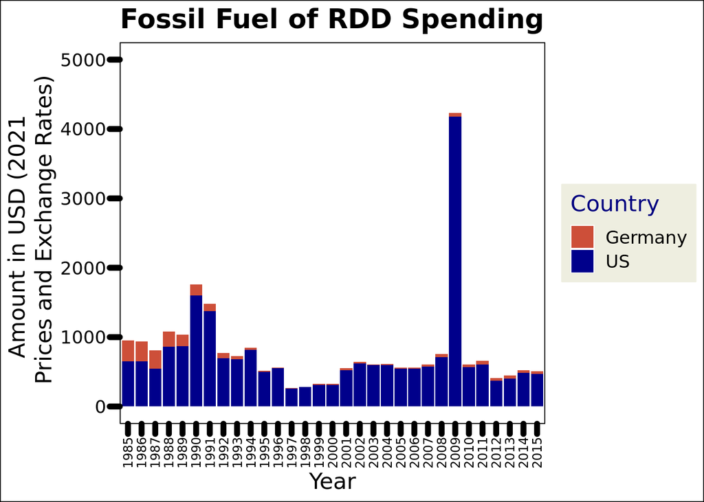

US and Germany Fossil Fuel RDD Spending 1985 to 2015. Bar graph used to visually compare relative magnitude of total spending.

```r
# Create the US and Germ fossil fuel bar plot
US.Germ.Fossil.fuel.Bar.plot <- ggplot(US.and.Germany.RDD, aes(x = Year, y= Fossil.Fuel, fill= Country)) +
  geom_bar(stat= "identity", position = "stack") +
  geom_bar(stat= "identity", position = "stack") +
  scale_fill_manual(values = c("tomato3", "darkblue")) +
  ylim(0, 5000) +
  labs(fill = "Country")+
  theme(axis.text.x = element_text(angle = 90, vjust = 0.5, hjust=1, size = 9)) +
  labs(title = "Fossil Fuel of RDD Spending",
       y="Amount in USD (2021 \n Prices and Exchange Rates)",
       x="Year")
print(US.Germ.Fossil.fuel.Bar.plot)
```

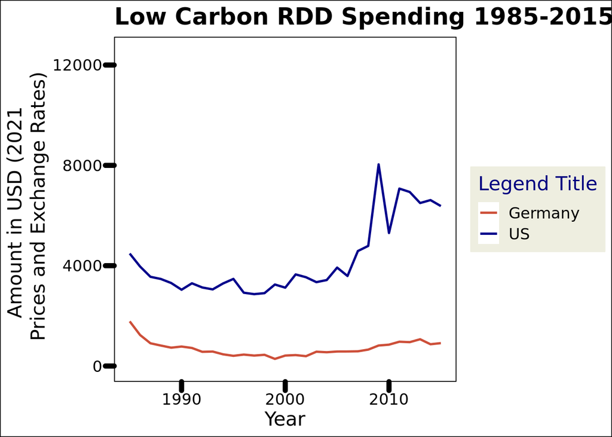

US and Germany Low Carbon Spending 1985 to 2015. Line graph used to visualize potential trends.

```r
#Low Carbon Germ and US Line Plot
US.Germ.lowC.plot <- ggplot(US.and.Germany.RDD,
                              aes(x = Date,
                                  y = Low.Carbon.Energy,
                                  color = Country)) +
  geom_line(size= 0.9) +
  ylim(0, 12500) +
  scale_color_manual(values = c("tomato3", "darkblue")) +
  labs(title = "Low Carbon RDD Spending 1985-2015",
       y="Amount in USD (2021 \n Prices and Exchange Rates)",
       x="Year",
       color= "Legend Title")

print(US.Germ.lowC.plot)
```

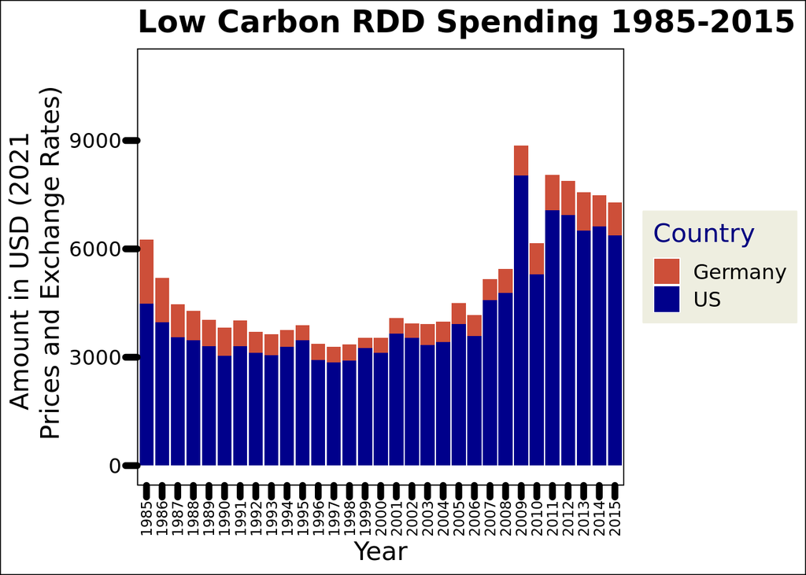

US and Germany Low Carbon RDD Spending 1985 to 2015, Bar graph used to visually compare relative magnitude of total spending.

```r
# Create the US and Germ Low Carbon bar plot
US.Germ.low.carbon.Bar.plot <- ggplot(US.and.Germany.RDD, aes(x = Year, y= Low.Carbon.Energy, fill= Country)) +
  geom_bar(stat= "identity", position = "stack") +
  geom_bar(stat= "identity", position = "stack") +
  scale_fill_manual(values = c("tomato3", "darkblue")) +
  ylim(0, 11000) +
  labs(fill = "Country")+
  theme(axis.text.x = element_text(angle = 90, vjust = 0.5, hjust=1, size = 9)) +
  labs(title = "Low Carbon RDD Spending 1985-2015",
       y="Amount in USD (2021 \n Prices and Exchange Rates)",
       x="Year")
print(US.Germ.low.carbon.Bar.plot)
```

# Analysis

Our analysis of this dataset focuses on comparing the mean investment YoY difference of the Pre-Obama era and the mean investment YoY difference of the Obama era. However, we need to ensure any changes in investment is unique to the Obama administration and not occurring globally. Therefore, we will also utilize t-tests to compare US investments to Germany’s within the same time period.

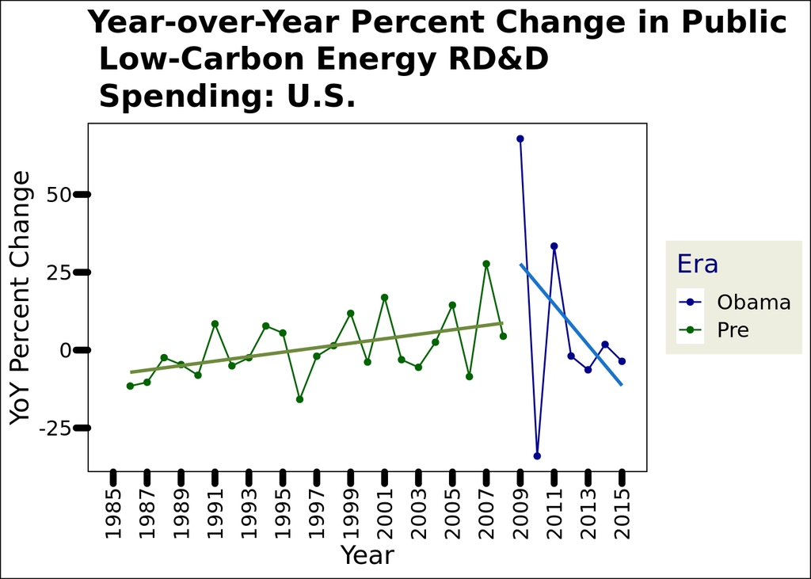

US Year over Year RDD Spending 1985 to 2015

```r
#plotting the pre-Obama data
RDD.US.Eras.plot <- RDD.US.Eras %>%
  ggplot(
         aes(x= Date,
             y= Percent.Change,
             color= Era)) +
  geom_line() +
  geom_point() +
  geom_smooth(data = subset(RDD.US.Eras, Era == "Pre"), method = "lm", se=FALSE, color= "darkolivegreen4") +
  geom_smooth(data = subset(RDD.US.Eras, Era == "Obama"), method = "lm", se=FALSE, color= "dodgerblue3") +
  labs(title = "Year-over-Year Percent Change in Public \n Low-Carbon Energy RD&D \n Spending: U.S.",
       y="YoY Percent Change",
       x="Year") +
  scale_color_manual(values = c("darkblue", "darkgreen")) +
  scale_x_date(date_breaks = "2 years", date_labels = "%Y") +
  our_theme +
  theme(axis.text.x = element_text(angle = 90, vjust = 0.5, hjust=1))

print(RDD.US.Eras.plot)
```

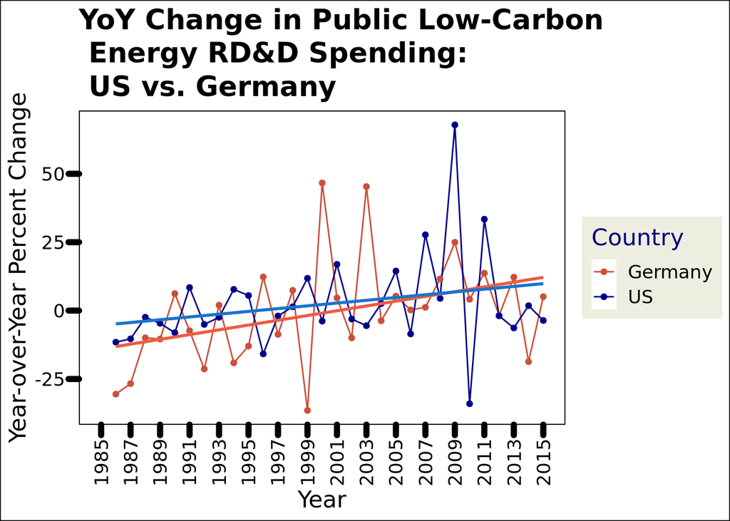

US and Germany Year over Year RDD Spending 1985 to 2015

```r
#plotting the data
US.Germany.RDD.plot <- ggplot(US.and.Germany.RDD,
                              aes(x = Date,
                                  y = Percent.Change,
                                  color = Country)) +
  geom_line() +
  geom_point() +
  geom_smooth(data = subset(US.and.Germany.RDD, Country == "Germany"), method = "lm", se=FALSE, color= "tomato2") +
  geom_smooth(data = subset(RDD.US.Eras, Country == "US"), method = "lm", se=FALSE, color= "dodgerblue3") +
  scale_color_manual(values = c("tomato3", "darkblue")) +
  labs(title = "YoY Change in Public Low-Carbon \n Energy RD&D Spending: \n US vs. Germany",
       y="Year-over-Year Percent Change",
       x="Year") +
  scale_x_date(date_breaks = "2 years", date_labels = "%Y") +
  our_theme +
  theme(axis.text.x = element_text(angle = 90, vjust = 0.5, hjust=1))

print(US.Germany.RDD.plot)
```

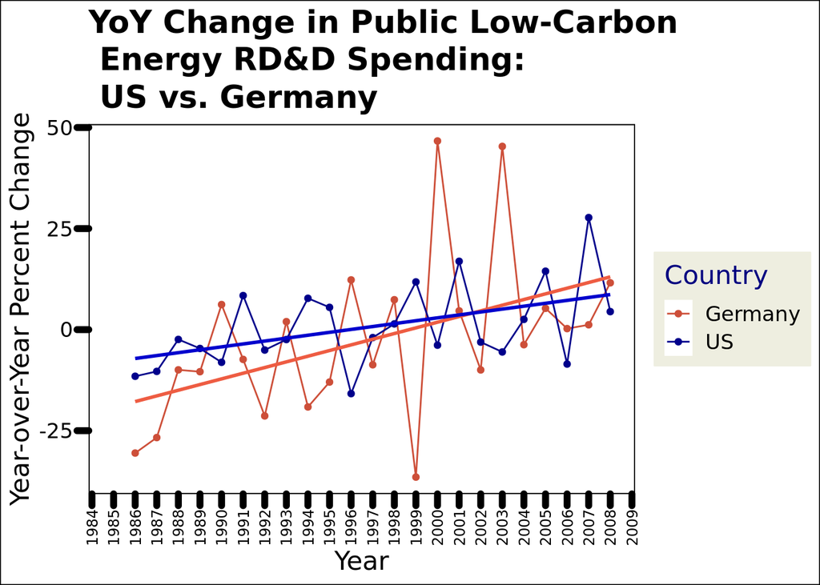

US and Germany Year over Year RDD Spending 1985 to 2008

```r
#plotting the data
US.Germany.RDD.pre.plot <- US.and.Germany.RDD %>%
  filter(Era == "Pre") %>%
  ggplot(aes(x = Date,
             y = Percent.Change,
             color = Country)) +
  geom_line() +
  geom_point() +
  geom_smooth(data = subset(US.and.Germany.RDD, Country == "Germany" & Era == "Pre"), method = "lm", se=FALSE, color= "tomato2") +
  geom_smooth(data = subset(RDD.US.Eras, Country == "US" & Era == "Pre"), method = "lm", se=FALSE, color= "blue3") +
  scale_color_manual(values = c("tomato3", "darkblue")) +
  labs(title = "YoY Change in Public Low-Carbon \n Energy RD&D Spending: \n US vs. Germany",
       y="Year-over-Year Percent Change",
       x="Year") +
  scale_x_date(date_breaks = "1 years", date_labels = "%Y") +
  our_theme +
  theme(axis.text.x = element_text(angle = 90, vjust = 0.5, hjust=1, size=9))

print(US.Germany.RDD.pre.plot)
```